# Problem set 4, part II: Competition and other 2-species interactions

# Plot the phase planes of all 6 species interactions

There is one question for this second part of problem set 4. Specifically, I want you to plot *each* of the different outcomes of *each* of the 6 types of 2-species interaction. The interactions and the number of outcomes are:

1. Neutralism: 1 outcome
2. Amensalism: 2 outcomes
3. Commensalism: 1 outcome
4. Mutualism: 2 outcomes
5. Predator-prey (i.e., enemy-victim): 2 outcomes
6. Competition: 3 outcomes

Note that the outcomes include combinations within an interaction (e.g., there are only 3 outcomes for competition because I am treating species 1 outcompeting species 2 and vice versa as the same thing; same could be said for amensalism, etc.).

For each phase plane, please:

- Include a vector field
- Show the nullclines for each species; including the trivial ones
- Show all the same type of interaction plots of 1 row and *n*-outcome columns. Use `par(mfrow = c(1, n))` with *n* being the number of columns before each set of plots. You might want to change the space around each plot, too,by passing the `mar =` argument to `par()`. Set `mar` to a 4-element vector for the space around the bottom, left, top, and right. The default in R is `mar = c(`5.1, 4.1, 4.1, 2.1`)`. Play around with the margin space until it looks good.
- Label each plot with `main =` to a string with the outcome as the title
- Label each interaction as its own heading (e.g., with # or ##)

```r
  library(package = "deSolve")
  library(package = "phaseR")
```

# Neutralism

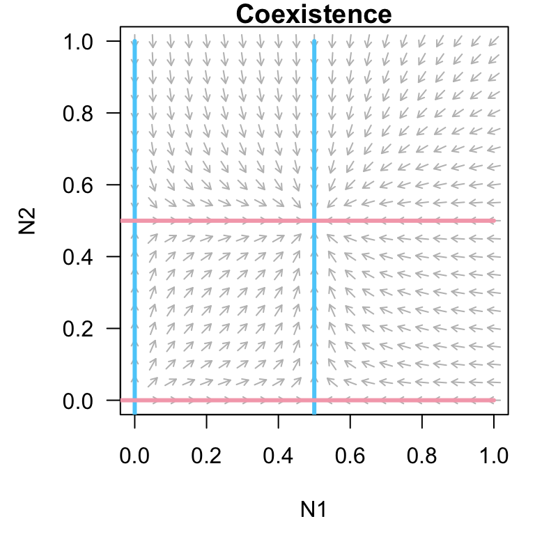

```r
  neut <- function(t, y, p) {
    with(as.list(c(y, p)), {
      dN1 <- r1*N1 - alpha1*N1*N1
      dN2 <- r2*N2 - alpha2*N2*N2
      return(list(c(dN1, dN2)))
    })
  }
  parms_vec <- c(r1 = 1, r2 = 1, alpha1 = 2, alpha2 = 2)
  name_vec <- c("N1", "N2")
  lims_vec <- c(0, 1)

  par(mar = c(4.5, 4.5, 1, 1))
  plot(x = NA, type = "n", xlim = lims_vec, ylim = lims_vec, xlab = "N1", ylab = "N2", las = 1, main = "Coexistence")
  trash <- flowField(deriv = neut, xlim = lims_vec, ylim = lims_vec, parameters = parms_vec, state.names = name_vec)
  trash <- nullclines(deriv = neut, xlim = c(-0.1, lims_vec[2]), ylim = c(-0.1, lims_vec[2]), parameters = parms_vec, state.names = name_vec, add.legend = FALSE, col = c("#5BCEFA", "#F5A9B8"), lwd = 3)
```

# Amensalism

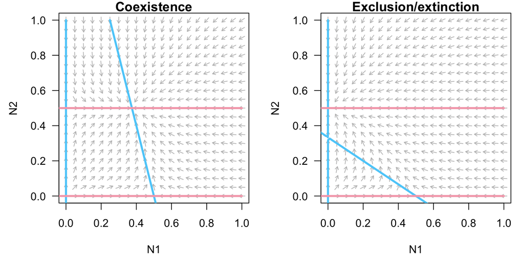

```r
  amen <- function(t, y, p) {
    with(as.list(c(y, p)), {
      dN1 <- r1*N1 - alpha1*N1*N1 - beta1*N1*N2
      dN2 <- r2*N2 - alpha2*N2*N2
      return(list(c(dN1, dN2)))
    })
  }
  parms_vec_1 <- c(r1 = 1, r2 = 1, alpha1 = 2, alpha2 = 2, beta1 = 0.5)
  parms_vec_2 <- c(r1 = 1, r2 = 1, alpha1 = 2, alpha2 = 2, beta1 = 3)
  name_vec <- c("N1", "N2")
  lims_vec <- c(0, 1)

  par(mar = c(4.5, 4.5, 1, 1), mfrow = c(1, 2))
  plot(x = NA, type = "n", xlim = lims_vec, ylim = lims_vec, xlab = "N1", ylab = "N2", las = 1, main = "Coexistence")
  trash <- flowField(deriv = amen, xlim = lims_vec, ylim = lims_vec, parameters = parms_vec_1, state.names = name_vec)
  trash <- nullclines(deriv = amen, xlim = c(-0.1, lims_vec[2]), ylim = c(-0.1, lims_vec[2]), parameters = parms_vec_1, state.names = name_vec, add.legend = FALSE, col = c("#5BCEFA", "#F5A9B8"), lwd = 3)

    plot(x = NA, type = "n", xlim = lims_vec, ylim = lims_vec, xlab = "N1", ylab = "N2", las = 1, main = "Exclusion/extinction")
  trash <- flowField(deriv = amen, xlim = lims_vec, ylim = lims_vec, parameters = parms_vec_2, state.names = name_vec)
  trash <- nullclines(deriv = amen, xlim = c(-0.1, lims_vec[2]), ylim = c(-0.1, lims_vec[2]), parameters = parms_vec_2, state.names = name_vec, add.legend = FALSE, col = c("#5BCEFA", "#F5A9B8"), lwd = 3)
```

# Commensalism

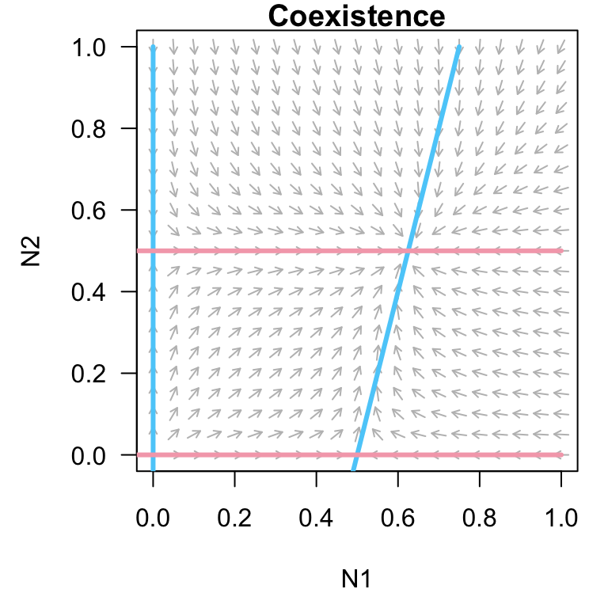

```r
  comm <- function(t, y, p) {
    with(as.list(c(y, p)), {
      dN1 <- r1*N1 - alpha1*N1*N1 + beta1*N1*N2
      dN2 <- r2*N2 - alpha2*N2*N2
      return(list(c(dN1, dN2)))
    })
  }
  parms_vec <- c(r1 = 1, r2 = 1, alpha1 = 2, alpha2 = 2, beta1 = 0.5)
  name_vec <- c("N1", "N2")
  lims_vec <- c(0, 1)

  par(mar = c(4.5, 4.5, 1, 1))
  plot(x = NA, type = "n", xlim = lims_vec, ylim = lims_vec, xlab = "N1", ylab = "N2", las = 1, main = "Coexistence")
  trash <- flowField(deriv = comm, xlim = lims_vec, ylim = lims_vec, parameters = parms_vec, state.names = name_vec)
  trash <- nullclines(deriv = comm, xlim = c(-0.1, lims_vec[2]), ylim = c(-0.1, lims_vec[2]), parameters = parms_vec, state.names = name_vec, add.legend = FALSE, col = c("#5BCEFA", "#F5A9B8"), lwd = 3)
```

# Mutualism

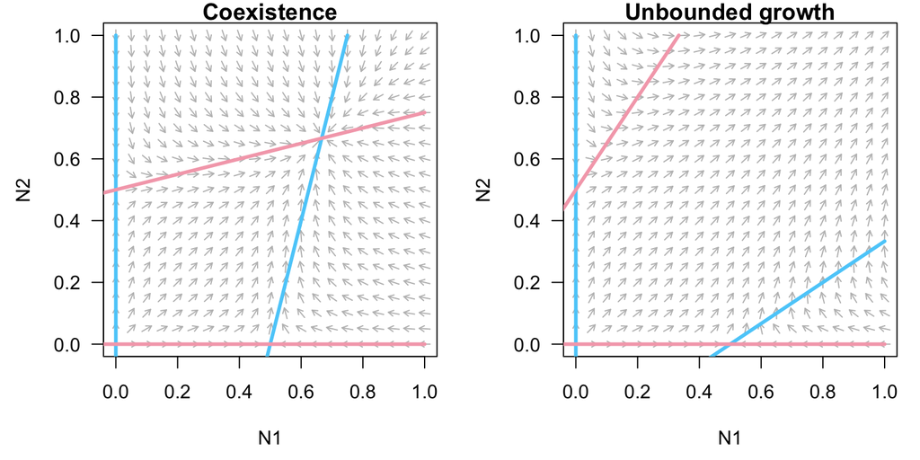

```r
  mut <- function(t, y, p) {
    with(as.list(c(y, p)), {
      dN1 <- r1*N1 - alpha1*N1*N1 + beta1*N1*N2
      dN2 <- r2*N2 - alpha2*N2*N2 + beta2*N1*N2
      return(list(c(dN1, dN2)))
    })
  }
  parms_vec_1 <- c(r1 = 1, r2 = 1, alpha1 = 2, alpha2 = 2, beta1 = 0.5, beta2 = 0.5)
  parms_vec_2 <- c(r1 = 1, r2 = 1, alpha1 = 2, alpha2 = 2, beta1 = 3, beta2 = 3)
  name_vec <- c("N1", "N2")
  lims_vec <- c(0, 1)

  par(mar = c(4.5, 4.5, 1, 1), mfrow = c(1, 2))
  plot(x = NA, type = "n", xlim = lims_vec, ylim = lims_vec, xlab = "N1", ylab = "N2", las = 1, main = "Coexistence")
  trash <- flowField(deriv = mut, xlim = lims_vec, ylim = lims_vec, parameters = parms_vec_1, state.names = name_vec)
  trash <- nullclines(deriv = mut, xlim = c(-0.1, lims_vec[2]), ylim = c(-0.1, lims_vec[2]), parameters = parms_vec_1, state.names = name_vec, add.legend = FALSE, col = c("#5BCEFA", "#F5A9B8"), lwd = 3)

  plot(x = NA, type = "n", xlim = lims_vec, ylim = lims_vec, xlab = "N1", ylab = "N2", las = 1, main = "Unbounded growth")
  trash <- flowField(deriv = mut, xlim = lims_vec, ylim = lims_vec, parameters = parms_vec_2, state.names = name_vec)
  trash <- nullclines(deriv = mut, xlim = c(-0.1, lims_vec[2]), ylim = c(-0.1, lims_vec[2]), parameters = parms_vec_2, state.names = name_vec, add.legend = FALSE, col = c("#5BCEFA", "#F5A9B8"), lwd = 3)
```

# Predator-prey

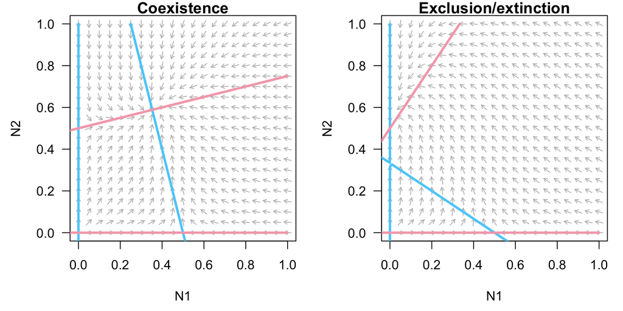

```r
  pp <- function(t, y, p) {
    with(as.list(c(y, p)), {
      dN1 <- r1*N1 - alpha1*N1*N1 - beta1*N1*N2
      dN2 <- r2*N2 - alpha2*N2*N2 + beta2*N1*N2
      return(list(c(dN1, dN2)))
    })
  }
  parms_vec_1 <- c(r1 = 1, r2 = 1, alpha1 = 2, alpha2 = 2, beta1 = 0.5, beta2 = 0.5)
  parms_vec_2 <- c(r1 = 1, r2 = 1, alpha1 = 2, alpha2 = 2, beta1 = 3, beta2 = 3)
  name_vec <- c("N1", "N2")
  lims_vec <- c(0, 1)

  par(mar = c(4.5, 4.5, 1, 1), mfrow = c(1, 2))
  plot(x = NA, type = "n", xlim = lims_vec, ylim = lims_vec, xlab = "N1", ylab = "N2", las = 1, main = "Coexistence")
  trash <- flowField(deriv = pp, xlim = lims_vec, ylim = lims_vec, parameters = parms_vec_1, state.names = name_vec)
  trash <- nullclines(deriv = pp, xlim = c(-0.1, lims_vec[2]), ylim = c(-0.1, lims_vec[2]), parameters = parms_vec_1, state.names = name_vec, add.legend = FALSE, col = c("#5BCEFA", "#F5A9B8"), lwd = 3)

  plot(x = NA, type = "n", xlim = lims_vec, ylim = lims_vec, xlab = "N1", ylab = "N2", las = 1, main = "Exclusion/extinction")
  trash <- flowField(deriv = pp, xlim = lims_vec, ylim = lims_vec, parameters = parms_vec_2, state.names = name_vec)
  trash <- nullclines(deriv = pp, xlim = c(-0.1, lims_vec[2]), ylim = c(-0.1, lims_vec[2]), parameters = parms_vec_2, state.names = name_vec, add.legend = FALSE, col = c("#5BCEFA", "#F5A9B8"), lwd = 3)
```

# Competition

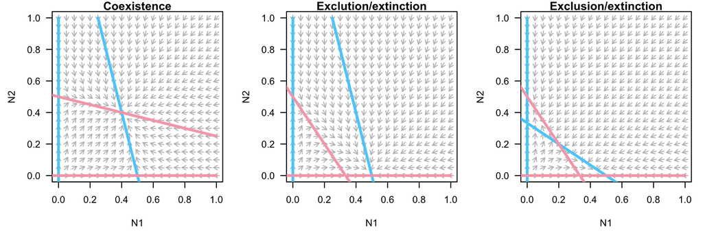

```r
  comp <- function(t, y, p) {
    with(as.list(c(y, p)), {
      dN1 <- r1*N1 - alpha1*N1*N1 - beta1*N1*N2
      dN2 <- r2*N2 - alpha2*N2*N2 - beta2*N1*N2
      return(list(c(dN1, dN2)))
    })
  }
  parms_vec_1 <- c(r1 = 1, r2 = 1, alpha1 = 2, alpha2 = 2, beta1 = 0.5, beta2 = 0.5)
  parms_vec_2 <- c(r1 = 1, r2 = 1, alpha1 = 2, alpha2 = 2, beta1 = 0.5, beta2 = 3)
  parms_vec_3 <- c(r1 = 1, r2 = 1, alpha1 = 2, alpha2 = 2, beta1 = 3, beta2 = 3)
  name_vec <- c("N1", "N2")
  lims_vec <- c(0, 1)

  par(mar = c(4.5, 4.5, 1, 1), mfrow = c(1, 3))
  plot(x = NA, type = "n", xlim = lims_vec, ylim = lims_vec, xlab = "N1", ylab = "N2", las = 1, main = "Coexistence")
  trash <- flowField(deriv = comp, xlim = lims_vec, ylim = lims_vec, parameters = parms_vec_1, state.names = name_vec)
  trash <- nullclines(deriv = comp, xlim = c(-0.1, lims_vec[2]), ylim = c(-0.1, lims_vec[2]), parameters = parms_vec_1, state.names = name_vec, add.legend = FALSE, col = c("#5BCEFA", "#F5A9B8"), lwd = 3)

  plot(x = NA, type = "n", xlim = lims_vec, ylim = lims_vec, xlab = "N1", ylab = "N2", las = 1, main = "Exclution/extinction")
  trash <- flowField(deriv = comp, xlim = lims_vec, ylim = lims_vec, parameters = parms_vec_2, state.names = name_vec)
  trash <- nullclines(deriv = comp, xlim = c(-0.1, lims_vec[2]), ylim = c(-0.1, lims_vec[2]), parameters = parms_vec_2, state.names = name_vec, add.legend = FALSE, col = c("#5BCEFA", "#F5A9B8"), lwd = 3)

   plot(x = NA, type = "n", xlim = lims_vec, ylim = lims_vec, xlab = "N1", ylab = "N2", las = 1, main = "Exclusion/extinction")
  trash <- flowField(deriv = comp, xlim = lims_vec, ylim = lims_vec, parameters = parms_vec_3, state.names = name_vec)
  trash <- nullclines(deriv = comp, xlim = c(-0.1, lims_vec[2]), ylim = c(-0.1, lims_vec[2]), parameters = parms_vec_3, state.names = name_vec, add.legend = FALSE, col = c("#5BCEFA", "#F5A9B8"), lwd = 3)
```